# Environment-domain quality of life in Brazilian medical students

Dataset 7: Resilience, learning environment and quality of life in Brazilian medical students

RSR feasibility analysis

2026-08-03

# Introduction

Tempski and colleagues surveyed a random sample of 1,350 students at 22 Brazilian medical schools in 2011-2012, measuring quality of life (WHOQOL-BREF), the perceived educational environment (DREEM), resilience, depressive symptoms and anxiety in a single cross-sectional questionnaire (Tempski et al., *PLOS ONE* 2015; doi:10.1371/journal.pone.0131535). The environment domain of the WHOQOL-BREF asks about financial resources, physical safety, home environment, transport, access to health care, opportunities for recreation and access to information - the material circumstances of a student’s life rather than their mood. It is the domain most likely to differ between schools and cities, which makes the two school-level variables in this file directly relevant.

**Aim.** Among Brazilian medical students, we examined which of sex, stage of the course, school legal status, school location, the perceived educational environment, resilience and trait anxiety are independently associated with environment-domain quality of life, mutually adjusting for the others.

This is a *Purpose 3* analysis: several predictors are of interest and the question is which remain associated with the outcome after mutual adjustment.

# Methods

**Data source.** Multicentre cross-sectional survey of a random sample of 1,350 students drawn from 22 medical schools across Brazil, stratified by stage of the course (basic sciences, clinical sciences, clerkship). All variables used here are complete.

**Variables.** The outcome is `whoqol_environment`, the WHOQOL-BREF environment domain transformed to a 0-100 scale where higher is better. Predictors are sex (reference: female, the larger group), stage of the course (reference: basic sciences, the earliest stage), school legal status (reference: public, the larger group and the traditional Brazilian medical school), school location (reference: state capital, the larger group and the better-resourced setting), the DREEM global score (sum of the five DREEM subscales, higher = a more positive perceived educational environment), the resilience scale score (16-98) and the trait anxiety scale (20-80, higher = more anxious). All continuous predictors are modelled per one-unit increase.

Deliberate choices about construct overlap. `dreem_global` is used **instead of** its five subscales, which sum to it exactly. No other WHOQOL domain is used as a predictor, because they are subscales of the same instrument as the outcome. Of the three negative-affect scales, only `trait_anxiety` is included: it correlates 0.73 with `bdi_depression` and 0.70 with `state_anxiety`, and entering all three would split one construct across three collinear terms. Trait anxiety was chosen over state anxiety because it is the dispositional measure and therefore less likely to be a same-day consequence of the material circumstances being measured.

**Statistical analysis.** Linear regression (`lm()`), justified because the outcome is continuous and roughly symmetric. We fitted a univariable model for each predictor first, then a single multivariable model containing all of them. Predictors were chosen in advance on subject-matter grounds, not by significance. Significance threshold 0.05; estimates are reported with 95% confidence intervals. Assumptions were checked with `performance::check_model()`. Analysis used R version 4.6.0 (2026-04-24) with tidyverse, gtsummary and performance.

**Missing data.** Complete-case analysis: 1350 of 1350 rows were analysed (0 dropped).

# Results

## Sample characteristics

**Table 1. Sample characteristics.**

| **Characteristic** | **N** | **N = 1,350**<sup>1</sup> |
| --- | --- | --- |
| WHOQOL environment domain (0-100) | 1,350 | 66 (53, 75) |
| Sex | 1,350 |  |
| Female |  | 714 (53%) |
| Male |  | 636 (47%) |
| Stage of course | 1,350 |  |
| Basic sciences |  | 459 (34%) |
| Clinical sciences |  | 491 (36%) |
| Clerkship |  | 400 (30%) |
| School legal status | 1,350 |  |
| Public |  | 882 (65%) |
| Private |  | 468 (35%) |
| School location | 1,350 |  |
| State capital |  | 782 (58%) |
| Other city |  | 568 (42%) |
| DREEM global score (0-200) | 1,350 | 120 (101, 139) |
| Resilience score (16-98) | 1,350 | 81 (73, 88) |
| Trait anxiety (20-80) | 1,350 | 45 (37, 53) |

<sup>1</sup> Median (Q1, Q3); n (%)

The median environment-domain score was 65.6 out of 100. Just under two thirds of students attended public schools and just under three fifths attended a school in a state capital, so both school-level contrasts have adequate numbers on each side.

## Exploratory figure

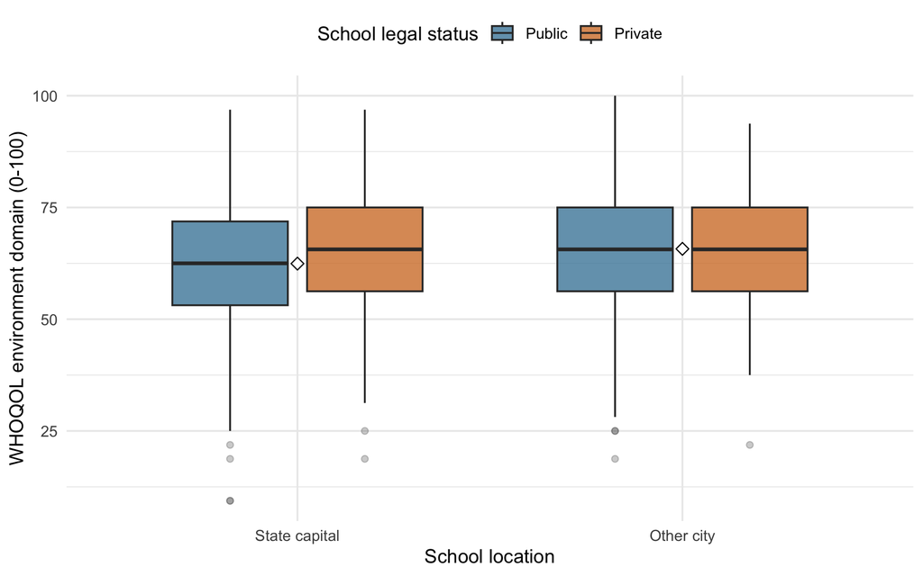

Figure 1. Environment-domain quality of life by school legal status and school location. Boxes show the median and interquartile range; the diamond marks the mean.

Students at schools outside the state capitals report slightly *better* environment-domain quality of life than those in the capitals, and the private-school advantage is small; the distributions overlap heavily, so any school-level differences are modest relative to between-student variation.

## Univariable models

**Univariable linear regression.**

| **Characteristic** | **Beta** | **95% CI** | **p-value** |
| --- | --- | --- | --- |
| Sex |  |  |  |
| Female | — | — |  |
| Male | 0.28 | -1.2, 1.8 | 0.7 |
| Stage of course |  |  |  |
| Basic sciences | — | — |  |
| Clinical sciences | 1.9 | 0.10, 3.7 | 0.039 |
| Clerkship | 1.1 | -0.80, 3.0 | 0.3 |
| School legal status |  |  |  |
| Public | — | — |  |
| Private | 2.7 | 1.2, 4.3 | <0.001 |
| School location |  |  |  |
| State capital | — | — |  |
| Other city | 3.3 | 1.8, 4.8 | <0.001 |
| DREEM global score (0-200) | 0.21 | 0.18, 0.24 | <0.001 |
| Resilience score (16-98) | 0.34 | 0.28, 0.39 | <0.001 |
| Trait anxiety (20-80) | -0.50 | -0.55, -0.44 | <0.001 |

Abbreviation: CI = Confidence Interval

The DREEM global score is the strongest crude predictor: each point is associated with a 0.210-point higher environment score (95% CI 0.185 to 0.235, p < 0.001), so a 20-point better perceived educational environment corresponds to about 4.2 points on the 0-100 scale. Trait anxiety runs the other way (-0.50 per point, 95% CI -0.55 to -0.44) and resilience is positively associated (0.34 per point). Both school-level variables are significant crudely: students outside a state capital score 3.31 points higher (p < 0.001) and private-school students 2.74 points higher (p = 0.0007). Sex shows no crude association (p = 0.71).

## Why adjustment is needed

The crude school-level contrasts are the ones most obviously in need of adjustment, and there are specific variables here that would confound them. **The DREEM global score** confounds the school legal status contrast: students at private schools rate their educational environment far more favourably (mean DREEM 128 versus 115 at public schools), and DREEM is itself strongly associated with the environment domain, so a crude “private schools are better” finding may be nothing more than the DREEM difference. **Trait anxiety** confounds both psychosocial predictors: dispositionally anxious students score lower on the resilience scale (*r* = -0.61), rate their educational environment more harshly (*r* = -0.43) and report worse material circumstances, so the crude resilience and DREEM coefficients each contain a share of trait anxiety. **Sex** is a third: women in this sample report substantially higher trait anxiety than men, which masks any direct sex difference in the environment domain until anxiety is held fixed. Finally, **stage of the course** is associated with both the perceived educational environment and with living circumstances (later-stage students are more likely to have moved out of the family home), so it must be held fixed before the DREEM coefficient can be read. Fitting all seven predictors together allows each estimate to be interpreted with the others held constant.

## Multivariable model

**Multivariable linear regression.**

| **Characteristic** | **Beta** | **95% CI** | **p-value** |
| --- | --- | --- | --- |
| Sex |  |  |  |
| Female | — | — |  |
| Male | -1.9 | -3.3, -0.59 | 0.005 |
| Stage of course |  |  |  |
| Basic sciences | — | — |  |
| Clinical sciences | 2.4 | 0.78, 3.9 | 0.003 |
| Clerkship | 2.5 | 0.83, 4.2 | 0.003 |
| School legal status |  |  |  |
| Public | — | — |  |
| Private | 0.55 | -0.87, 2.0 | 0.4 |
| School location |  |  |  |
| State capital | — | — |  |
| Other city | 2.6 | 1.3, 4.0 | <0.001 |
| DREEM global score (0-200) | 0.15 | 0.12, 0.18 | <0.001 |
| Resilience score (16-98) | -0.04 | -0.10, 0.03 | 0.3 |
| Trait anxiety (20-80) | -0.37 | -0.44, -0.29 | <0.001 |

Abbreviation: CI = Confidence Interval

**Model fit**

| Statistic | Value |
| --- | --- |
| R-squared | 0.250 |
| Adjusted R-squared | 0.246 |
| Residual SE | 12.23 |
| n | 1350 |
| Model df | 8 |

The model explains 25.0% of the variance (adjusted R-squared 0.246) - much less than for the psychological or physical domains, which is expected because material circumstances depend heavily on family resources that this survey did not measure. Holding the other predictors fixed, each DREEM point is associated with 0.152 (95% CI 0.123 to 0.181) points of environment-domain score (about 3.0 points per 20 DREEM points), and each trait-anxiety point with -0.37 (95% CI -0.44 to -0.29) points. Attending a school outside a state capital remains independently associated with a 2.64 (95% CI 1.31 to 3.96)-point higher score. Men score -1.93 (95% CI -3.28 to -0.59) points *lower* than women once anxiety is held fixed. Clinical-sciences students score 2.35 (95% CI 0.78 to 3.92) and clerkship students 2.50 (95% CI 0.83 to 4.17) points higher than basic-sciences students. Private schooling (0.55 (95% CI -0.87 to 1.97)) and resilience (-0.04 (95% CI -0.10 to 0.03)) show no independent association. These are conditional associations from a cross-sectional survey.

## Unadjusted versus adjusted

**Table 2. Unadjusted and adjusted estimates.**

| **Characteristic** | **Unadjusted** **Beta** | **Unadjusted** **95% CI** | **Unadjusted** **p-value** | **Adjusted** **Beta** | **Adjusted** **95% CI** | **Adjusted** **p-value** |
| --- | --- | --- | --- | --- | --- | --- |
| Sex |  |  |  |  |  |  |
| Female | — | — |  | — | — |  |
| Male | 0.28 | -1.2, 1.8 | 0.7 | -1.9 | -3.3, -0.59 | 0.005 |
| Stage of course |  |  |  |  |  |  |
| Basic sciences | — | — |  | — | — |  |
| Clinical sciences | 1.9 | 0.10, 3.7 | 0.039 | 2.4 | 0.78, 3.9 | 0.003 |
| Clerkship | 1.1 | -0.80, 3.0 | 0.3 | 2.5 | 0.83, 4.2 | 0.003 |
| School legal status |  |  |  |  |  |  |
| Public | — | — |  | — | — |  |
| Private | 2.7 | 1.2, 4.3 | <0.001 | 0.55 | -0.87, 2.0 | 0.4 |
| School location |  |  |  |  |  |  |
| State capital | — | — |  | — | — |  |
| Other city | 3.3 | 1.8, 4.8 | <0.001 | 2.6 | 1.3, 4.0 | <0.001 |
| DREEM global score (0-200) | 0.21 | 0.18, 0.24 | <0.001 | 0.15 | 0.12, 0.18 | <0.001 |
| Resilience score (16-98) | 0.34 | 0.28, 0.39 | <0.001 | -0.04 | -0.10, 0.03 | 0.3 |
| Trait anxiety (20-80) | -0.50 | -0.55, -0.44 | <0.001 | -0.37 | -0.44, -0.29 | <0.001 |

Abbreviation: CI = Confidence Interval

The most dramatic movement is **resilience**, which goes from a strongly significant 0.34 crude (p < 0.001) to -0.04 adjusted and non-significant (p = 0.32) - it even changes sign. The entire crude resilience association with material circumstances was trait anxiety: resilient students are, on this instrument, mostly non-anxious students. **Private schooling** does the same thing, from 2.74 points (p = 0.0007) to 0.55 (p = 0.45); once the DREEM score is held fixed the private-school advantage disappears, because private-school students rate their educational environment about 13 DREEM points higher on average and that, rather than the school’s legal status, is what tracked the environment domain. (School location is *not* the explanation here - private and public schools are almost identically distributed between capitals and other cities, 43% versus 41% outside a capital.) **Sex** moves in the opposite direction, a textbook suppression: crude 0.28 points and clearly non-significant (p = 0.71), adjusted -1.93 points and significant (p = 0.005). Women’s higher trait anxiety was concealing a modest male *disadvantage* on the environment domain.

**School location** barely moves - 3.31 crude to 2.64 adjusted, retaining 80% and remaining significant - so it is not explained away by any of the individual-level predictors and is the closest thing in this analysis to a genuine school-level finding. **The DREEM global score** shrinks moderately (0.210 to 0.152, 72% retained), and **stage of the course** strengthens slightly (clerkship 1.09 crude, non-significant, to 2.50 adjusted and significant).

## Diagnostics

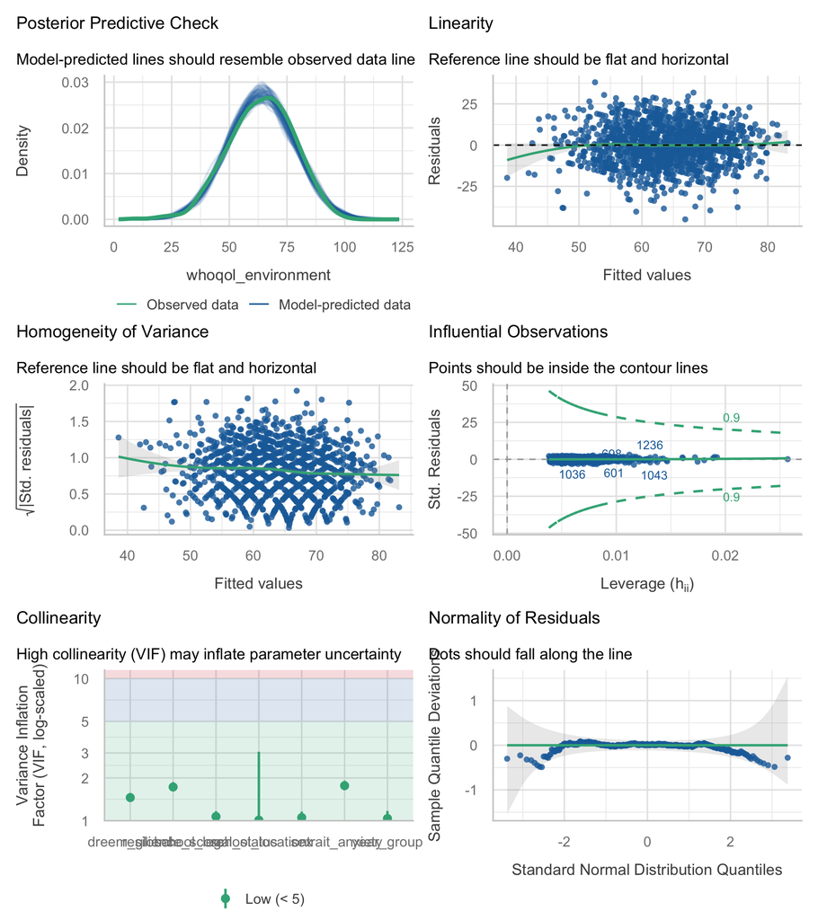

**Variance inflation factors**

| Term | VIF | Tolerance |
| --- | --- | --- |
| sex | 1.05 | 0.950 |
| year_group | 1.04 | 0.964 |
| school_legal_status | 1.07 | 0.934 |
| school_location | 1.01 | 0.990 |
| dreem_global | 1.46 | 0.687 |
| resilience_score | 1.73 | 0.579 |
| trait_anxiety | 1.76 | 0.567 |

**Linearity.** The fitted-versus-residual reference line is essentially flat across the fitted range, with only slight curvature at the extremes; the linear form is adequate.

**HC3 robust standard errors (sensitivity check)**

| term | estimate | robust SE | statistic | p.value |
| --- | --- | --- | --- | --- |
| (Intercept) | 63.254 | 4.549 | 13.90 | < 0.001 |
| sexMale | -1.934 | 0.678 | -2.85 | 0.00439 |
| year_groupClinical sciences | 2.352 | 0.808 | 2.91 | 0.00365 |
| year_groupClerkship | 2.497 | 0.863 | 2.89 | 0.00387 |
| school_legal_statusPrivate | 0.549 | 0.726 | 0.76 | 0.44952 |
| school_locationOther city | 2.635 | 0.669 | 3.94 | < 0.001 |
| dreem_global | 0.152 | 0.016 | 9.52 | < 0.001 |
| resilience_score | -0.035 | 0.036 | -0.97 | 0.32996 |
| trait_anxiety | -0.369 | 0.039 | -9.40 | < 0.001 |

No coefficient changes its significance status under HC3, so the heteroscedasticity - a floor/ceiling artefact of the bounded 0-100 scale - does not affect the conclusions.

**Influential points.** No observation exceeds the Cook’s distance threshold; the largest is 0.018.

**Collinearity.** The highest VIF is 1.76 (trait anxiety), with resilience at 1.73. All values are below 2 and comfortably under the threshold of 5. The two school-level variables are only weakly associated with each other in this sample (both VIFs near 1.1), so their separate contributions can be read with confidence.

# Discussion

**Limitations.** *Clustering is not modelled, and this matters more here than for any other outcome in the file.* The strongest finding is a school-level contrast, but students were sampled from 22 schools and the released file carries no school identifier - only `school_legal_status` and `school_location`. Two schools in the same city share cost of living, transport and campus facilities, so the effective number of independent units behind the location coefficient is closer to 22 than to 1350. The reported standard error for `school_location` is therefore substantially too small and its p-value too optimistic; with a random intercept for school this finding might well not survive. *No socioeconomic measure.* Family income, which is the obvious driver of every item in the environment domain, is not in the file, so residual confounding of both school-level contrasts by family wealth is near-certain. *Cross-sectional design and common-method bias.* DREEM, resilience, anxiety and WHOQOL were all self-reported at one sitting, so a generally negative respondent depresses all of them together. *Low explained variance.* An R-squared of 0.25 means the model is describing a small slice of what determines this outcome, and predictions for individuals would be poor.

**Future work.** Retain the school identifier and add a family-income measure, then fit a mixed model with a random intercept for school to test whether the capital-versus-other-city difference is a real contextual effect or an artefact of a handful of schools.

# Feasibility notes

*Not part of a student report.*